# Humanized Sterol Biosynthesis (HsS) Growth Analysis

Michelle Vandeloo

07/04/2022

This document describes the analysis pipeline for the growth curve analysis used in Masters thesis. The required packages are: tidyverse, viridis, matrixStats, pracma, ggplot2, gridExtra, and lemon.

```r
gc_rep <- read.csv(paste(raw_path, "/gc_replicates.csv", sep = ""), header = TRUE, fileEncoding = 'UTF-8-BOM')

gc_long <- gc_rep %>%
  pivot_longer(c(2:ncol(.)), names_to = "strain", values_to = "OD600") %>%
  filter(!str_detect(strain, "het"))

gc_org <- gc_long %>%
  separate(strain, into = c("strain", "replicate")) %>%
  pivot_wider(names_from = replicate, values_from = OD600)

gc_names = c("time", "strain", "rep_1", "rep_2", "rep_3")

names(gc_org) <- gc_names
```

Mean and standard error are calculated for every experimental read. (Names indicate which gene was humanized in that strain, except for the names RSHIP (HsS5.1), RSHIP4 (HsS6.1), RSHIP4N (HsS7.1), RSHIP4NT (HsS8.1), RSHIP4NTC (HsS9.2), RSHIP4NTK (HsS9.1).)

```r
gc_stat <- gc_org %>%
  mutate(mean = rowMeans(.[c("rep_1", "rep_2", "rep_3")], na.rm = TRUE),
         error = rowSds(as.matrix(.[c("rep_1", "rep_2", "rep_3")]), na.rm = TRUE)/sqrt(length(.[c("rep_1", "rep_2", "rep_3")]))) %>%
  filter(strain %in% c("cyp51a1", "hmgcr", "lbr", "mvk", "nsdhl", "pmvk", "rship", "rship4", "rship4n", "rship4nt", "rship4ntc", "rship4ntk", "sc4mol", "sqle", "wt"))
```

```r
AUCdata <- gc_long %>%
  select(strain, time, OD600)

AUC <- function(dat) {
  strains <- pull(unique(dat[,1]))
  auc <- c()
  for (i in 1:length(strains)) {
    temp <- filter(dat, strain %in% strains[i])
    auc <- c(auc, trapz(pull(temp, 2), pull(temp, 3)))
  }
  newdat <- data.frame(strains, auc)
  newdat <- mutate(newdat, prop = auc/124.73264)
  return <- newdat
}

aucs <- AUC(AUCdata) %>%
   filter(!str_detect(strains, "rship")) %>%
  separate(strains, into = c("strain", "replicate")) %>%
  select(strain, replicate, prop) %>%
  pivot_wider(names_from = replicate, values_from = prop)

aucs_names = c("strain", "rep_1", "rep_2", "rep_3")

names(aucs) <- aucs_names

aucs_reps <- aucs %>%
  mutate(mean = rowMeans(.[c("rep_1", "rep_2", "rep_3")], na.rm = TRUE),
         error = rowSds(as.matrix(.[c("rep_1", "rep_2", "rep_3")]), na.rm = TRUE)/sqrt(length(.[c("rep_1", "rep_2", "rep_3")])),
         sd = rowSds(as.matrix(.[c("rep_1", "rep_2", "rep_3")]), na.rm = TRUE))

aucs_reps$strain <- as.character(aucs_reps$strain)
aucs_reps$strain <- factor(aucs_reps$strain, levels = c("wt", "hmgcr", "mvk", "pmvk", "sqle", "cyp51a1", "lbr", "sc4mol", "nsdhl"))

auc_gg <- aucs_reps %>%
  select(strain, mean, error) %>%
  ggplot() +
  geom_bar(mapping = aes(x = strain, y = mean, fill = factor(strain)), stat = "identity") +
  geom_errorbar(aes(x = strain,
                    ymin = mean - error,
                    ymax = mean + error),
                width=.2,
                position=position_dodge(.9)) +
  scale_x_discrete(breaks = c("wt", "hmgcr", "mvk", "pmvk", "sqle", "cyp51a1", "lbr", "sc4mol", "nsdhl"),
                   labels = c("WT", "HsS1.1", "HsS1.2", "HsS1.3", "HsS1.4", "HsS1.5", "HsS1.6", "HsS1.7", "HsS1.8")) +
  xlab("") +
  ylab("AUC compared to WT") +
  theme(panel.background = element_blank()) +
  scale_fill_viridis_d("Strain", labels = c("WT", "HsS1.1 (HMGCR)", "HsS1.2 (MVK)", "HsS1.3 (PMVK)", "HsS1.4 (SQLE)", "HsS1.5 (CYP51A1)", "HsS1.6 (LBR)", "HsS1.7 (SC4MOL)", "HsS1.8 (NSDHL)"))

# print(ggplot_build(auc_gg)$data[[1]][,1])
# colours used:
# lbr = "#5DC863FF"
# hmgcr = "#472D7BFF"
# sqle = "#21908CFF"
# sc4mol = "#AADC32FF"
# pmvk = "#2C728EFF"
# nsdhl = "#FDE725FF"
# cyp51a1 = "#27AD81FF"
# wt = "#440154FF"
# mvk = "#3B528BFF"
```

For each of the single-gene humanized strains (HsS1.X), growth is plotted, matching colour values to the previous figure. Every strain is compared to the wild-type as a reference.

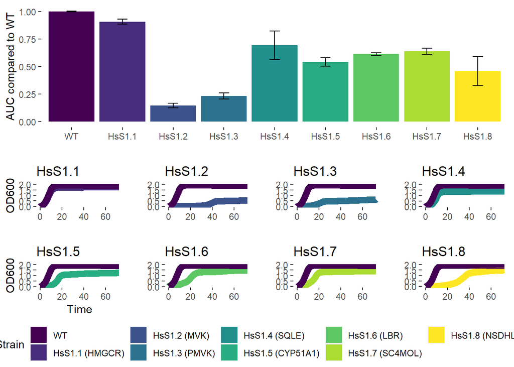

```r
hmgcr <- gc_stat %>%
  filter(strain == "hmgcr" | strain == "wt") %>%
  ggplot(aes(x = time, y = mean)) +
  geom_line(mapping = aes(colour=strain), size=3) +
  geom_ribbon(aes(ymin = mean - error,
                  ymax = mean + error,
                  fill = strain), alpha = 0.2) +
  theme(panel.background = element_blank(), legend.position = "none") +
  xlab("") +
  ylab("OD600") +
  ggtitle("HsS1.1") +
  scale_colour_manual(values=c("#472D7BFF", "#440154FF"), aesthetics = c("colour", "fill"))

mvk <- gc_stat %>%
  filter(strain == "mvk" | strain == "wt") %>%
  ggplot(aes(x = time, y = mean)) +
  geom_line(mapping = aes(colour=strain), size=3) +
  geom_ribbon(aes(ymin = mean - error,
                  ymax = mean + error,
                  fill = strain), alpha = 0.2) +
  theme(panel.background = element_blank(), legend.position = "none") +
  xlab("") +
  ylab("") +
  ggtitle("HsS1.2") +
  scale_colour_manual(values=c("#3B528BFF", "#440154FF"), aesthetics = c("colour", "fill"))

pmvk <- gc_stat %>%
  filter(strain == "pmvk" | strain == "wt") %>%
  ggplot(aes(x = time, y = mean)) +
  geom_line(mapping = aes(colour=strain), size=3) +
  geom_ribbon(aes(ymin = mean - error,
                  ymax = mean + error,
                  fill = strain), alpha = 0.2) +
    theme(panel.background = element_blank(), legend.position = "none") +
  xlab("") +
  ylab("") +
  ggtitle("HsS1.3") +
  scale_colour_manual(values=c("#2C728EFF" , "#440154FF"), aesthetics = c("colour", "fill"))

sqle <- gc_stat %>%
  filter(strain == "sqle" | strain == "wt") %>%
  ggplot(aes(x = time, y = mean)) +
  geom_line(mapping = aes(colour=strain), size=3) +
  geom_ribbon(aes(ymin = mean - error,
                  ymax = mean + error,
                  fill = strain), alpha = 0.2) +
  xlab("") +
  ylab("") +
  ggtitle("HsS1.4") +
    theme(panel.background = element_blank(), legend.position = "none") +
  scale_colour_manual(values=c("#21908CFF", "#440154FF"), aesthetics = c("colour", "fill"))

cyp51a1 <- gc_stat %>%
  filter(strain == "cyp51a1" | strain == "wt") %>%
  ggplot(aes(x = time, y = mean)) +
  geom_line(mapping = aes(colour=strain), size=3) +
  geom_ribbon(aes(ymin = mean - error,
                  ymax = mean + error,
                  fill = strain), alpha = 0.2) +
  xlab("Time") +
  ylab("OD600") +
  ggtitle("HsS1.5") +
    theme(panel.background = element_blank(), legend.position = "none") +
  scale_colour_manual(values=c("#27AD81FF", "#440154FF"), aesthetics = c("colour", "fill"))

lbr <- gc_stat %>%
  filter(strain == "lbr" | strain == "wt") %>%
  ggplot(aes(x = time, y = mean)) +
  geom_line(mapping = aes(colour=strain), size=3) +
  geom_ribbon(aes(ymin = mean - error,
                  ymax = mean + error,
                  fill = strain), alpha = 0.2) +
  xlab("") +
  ylab("") +
  ggtitle("HsS1.6") +
    theme(panel.background = element_blank(), legend.position = "none") +
  scale_colour_manual(values=c("#5DC863FF", "#440154FF"), aesthetics = c("colour", "fill"))

sc4mol <- gc_stat %>%
  filter(strain == "sc4mol" | strain == "wt") %>%
  ggplot(aes(x = time, y = mean)) +
  geom_line(mapping = aes(colour=strain), size=3) +
  geom_ribbon(aes(ymin = mean - error,
                  ymax = mean + error,
                  fill = strain), alpha = 0.2) +
  xlab("") +
  ylab("") +
  ggtitle("HsS1.7") +
    theme(panel.background = element_blank(), legend.position = "none") +
  scale_colour_manual(values=c("#AADC32FF" , "#440154FF"), aesthetics = c("colour", "fill"))

nsdhl <- gc_stat %>%
  filter(strain == "nsdhl" | strain == "wt") %>%
  ggplot(aes(x = time, y = mean)) +
  geom_line(mapping = aes(colour=strain), size=3) +
  geom_ribbon(aes(ymin = mean - error,
                  ymax = mean + error,
                  fill = strain), alpha = 0.2) +
  xlab("") +
  ylab("") +
  ggtitle("HsS1.8") +
    theme(panel.background = element_blank(), legend.position = "none") +
  scale_colour_manual(values=c("#FDE725FF" , "#440154FF"), aesthetics = c("colour", "fill"))

grid_arrange_shared_legend(auc_gg, gridExtra::arrangeGrob(hmgcr, mvk, pmvk, sqle, cyp51a1, lbr, sc4mol, nsdhl, ncol = 4, nrow = 2), ncol = 1, nrow = 2)
```

We repeat the above (AUC data and growth curves) for the multi-gene strains (HsS5.1-HsS9.2).

```r
aucs_multi <- AUC(AUCdata) %>%
  filter(str_detect(strains, "rship") | str_detect(strains, "wt")) %>%
  separate(strains, into = c("strain", "replicate")) %>%
  select(strain, replicate, prop) %>%
  pivot_wider(names_from = replicate, values_from = prop)

names(aucs_multi) <- aucs_names

aucs_reps_multi <- aucs_multi %>%
  mutate(mean = rowMeans(.[c("rep_1", "rep_2", "rep_3")], na.rm = TRUE),
         error = rowSds(as.matrix(.[c("rep_1", "rep_2", "rep_3")]), na.rm = TRUE)/sqrt(length(.[c("rep_1", "rep_2", "rep_3")])),
         sd = rowSds(as.matrix(.[c("rep_1", "rep_2", "rep_3")]), na.rm = TRUE))

aucs_reps_multi$strain <- as.character(aucs_reps_multi$strain)
aucs_reps_multi$strain <- factor(aucs_reps_multi$strain, levels = c("wt", "rship", "rship4", "rship4n", "rship4nt", "rship4ntk", "rship4ntc"))

auc_gg_multi <- aucs_reps_multi %>%
  select(strain, mean, error) %>%
  ggplot() +
  geom_bar(mapping = aes(x = strain, y = mean, fill = factor(strain)), stat = "identity") +
  geom_errorbar(aes(x = strain,
                    ymin = mean - error,
                    ymax = mean + error),
                width=.2,
                position=position_dodge(.9)) +
  scale_x_discrete(breaks = c("wt", "rship", "rship4", "rship4n", "rship4nt", "rship4ntk", "rship4ntc"),
                   labels = c("WT", "HsS5.1", "HsS6.1", "HsS7.1", "HsS8.1", "HsS9.1", "HsS9.2")) +
  xlab("") +
  ylab("AUC compared to WT") +
  theme(panel.background = element_blank()) +
  scale_fill_viridis_d("Strain", labels = c("WT", "HsS5.1", "HsS6.1", "HsS7.1", "HsS8.1", "HsS9.1", "HsS9.2"), option = "plasma")

print(ggplot_build(auc_gg_multi)$data[[1]][,1])
```

```
## [1] "#5D01A6FF" "#9C179EFF" "#CC4678FF" "#0D0887FF" "#ED7953FF" "#F0F921FF"
## [7] "#FDB32FFF"
```

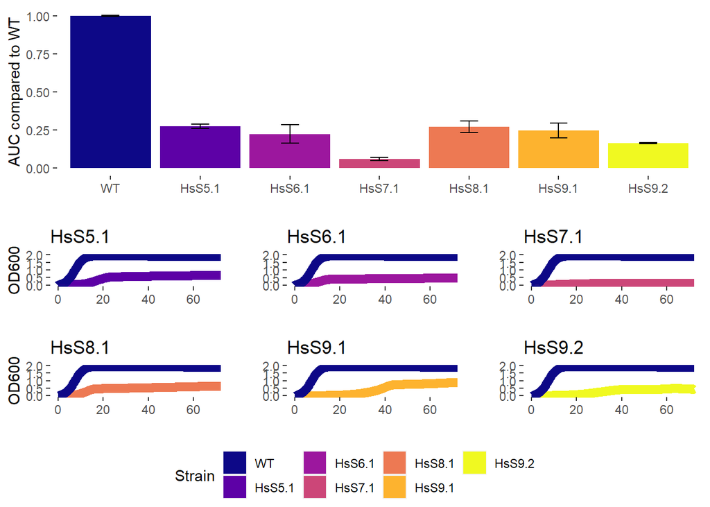

```r
# colours used:
#   wt = "#0D0887FF",
# rship = "#5D01A6FF",
# rship4 = "#9C179EFF",
# rship4n = "#CC4678FF",
# rship4nt = "#ED7953FF",
# rship4ntk = "#FDB32FFF",
# rship4ntc = "#F0F921FF"

rship <- gc_stat %>%
  filter(strain == "rship" | strain == "wt") %>%
  ggplot(aes(x = time, y = mean)) +
  geom_line(mapping = aes(colour=strain), size=3) +
  geom_ribbon(aes(ymin = mean - error,
                  ymax = mean + error,
                  fill = strain), alpha = 0.2) +
  xlab("") +
  ylab("OD600") +
  ggtitle("HsS5.1") +
  theme(panel.background = element_blank(), legend.position = "none") +
  scale_colour_manual(values=c("#5D01A6FF", "#0D0887FF"), aesthetics = c("colour", "fill"))

rship4 <- gc_stat %>%
  filter(strain == "rship4" | strain == "wt") %>%
  ggplot(aes(x = time, y = mean)) +
  geom_line(mapping = aes(colour=strain), size=3) +
  geom_ribbon(aes(ymin = mean - error,
                  ymax = mean + error,
                  fill = strain), alpha = 0.2) +
  xlab("") +
  ylab("") +
  ggtitle("HsS6.1") +
  theme(panel.background = element_blank(), legend.position = "none") +
  scale_colour_manual(values=c("#9C179EFF", "#0D0887FF"), aesthetics = c("colour", "fill"))

rship4n <- gc_stat %>%
  filter(strain == "rship4n" | strain == "wt") %>%
  ggplot(aes(x = time, y = mean)) +
  geom_line(mapping = aes(colour=strain), size=3) +
  geom_ribbon(aes(ymin = mean - error,
                  ymax = mean + error,
                  fill = strain), alpha = 0.2) +
  xlab("") +
  ylab("") +
  ggtitle("HsS7.1") +
  theme(panel.background = element_blank(), legend.position = "none") +
  scale_colour_manual(values=c("#CC4678FF", "#0D0887FF"), aesthetics = c("colour", "fill"))

rship4nt <- gc_stat %>%
  filter(strain == "rship4nt" | strain == "wt") %>%
  ggplot(aes(x = time, y = mean)) +
  geom_line(mapping = aes(colour=strain), size=3) +
  geom_ribbon(aes(ymin = mean - error,
                  ymax = mean + error,
                  fill = strain), alpha = 0.2) +
  xlab("") +
  ylab("OD600") +
  ggtitle("HsS8.1") +
  theme(panel.background = element_blank(), legend.position = "none") +
  scale_colour_manual(values=c("#ED7953FF", "#0D0887FF"), aesthetics = c("colour", "fill"))

rship4ntk <- gc_stat %>%
  filter(strain == "rship4ntk" | strain == "wt") %>%
  ggplot(aes(x = time, y = mean)) +
  geom_line(mapping = aes(colour=strain), size=3) +
  geom_ribbon(aes(ymin = mean - error,
                  ymax = mean + error,
                  fill = strain), alpha = 0.2) +
  xlab("") +
  ylab("") +
  ggtitle("HsS9.1") +
  theme(panel.background = element_blank(), legend.position = "none") +
  scale_colour_manual(values=c("#FDB32FFF", "#0D0887FF"), aesthetics = c("colour", "fill"))

rship4ntc <- gc_stat %>%
  filter(strain == "rship4ntc" | strain == "wt") %>%
  ggplot(aes(x = time, y = mean)) +
  geom_line(mapping = aes(colour=strain), size=3) +
  geom_ribbon(aes(ymin = mean - error,
                  ymax = mean + error,
                  fill = strain), alpha = 0.2) +
  xlab("") +
  ylab("") +
  ggtitle("HsS9.2") +
  theme(panel.background = element_blank(), legend.position = "none") +
  scale_colour_manual(values=c("#F0F921FF", "#0D0887FF"), aesthetics = c("colour", "fill"))

grid_arrange_shared_legend(auc_gg_multi, gridExtra::arrangeGrob(rship, rship4, rship4n, rship4nt, rship4ntk, rship4ntc, ncol = 3, nrow = 2), ncol = 1, nrow = 2)
```

Citations for packages used:

```r
print("Pracma: https://cran.r-project.org/web/packages/pracma/index.html")
```

```
## [1] "Pracma: https://cran.r-project.org/web/packages/pracma/index.html"
```

```r
print("Lemon: https://cran.r-project.org/web/packages/lemon/lemon.pdf")
```

```
## [1] "Lemon: https://cran.r-project.org/web/packages/lemon/lemon.pdf"
```